# Data Wrangling

Tyler Hill

3/8/2021

```r
# Load the necessary libraries
library(tidyverse)
library(lubridate)
library(sf)
```

## The Data

The data I am using comes from the [City of Seattle’s Open Data Program](https://data.seattle.gov/). I am using the following three data sets concerning the Seattle Police Department (SPD).

- [Terry Stops](https://data.seattle.gov/Public-Safety/Terry-Stops/28ny-9ts8)
- [Use of Force](https://data.seattle.gov/Public-Safety/Use-Of-Force/ppi5-g2bj)
- [SPD Officer Involved Shooting (OIS) Data](https://data.seattle.gov/Public-Safety/SPD-Officer-Involved-Shooting-OIS-Data/mg5r-efcm)

I will be using the shape files from [this data set](https://data.seattle.gov/dataset/Seattle-Police-Beats-2018-Present/ex83-w2uk) of Seattle Police Beats, 2018 to the present.

The data is in csv format. I will load in the individual files and clean them to meet my needs. Note, I am only keeping data from 2018 to the present as SPD changes their beats every few years and I only want to have to handle one shape file for this analysis. I feel like this still constitutes a meaningful time range to see recent trends.

### Terry Stops

```r
terry_df <- read.csv("Data/Terry_Stops.csv")
#View(terry_df)

terry_df <- terry_df %>%
  select( # No need for these columns for my analysis
    -c(GO...SC.Num, Initial.Call.Type, Officer.Squad, Call.Type, Sector)
    ) %>%
  mutate( # General cleaning of data for better analysis
    Beat = trimws(ifelse(Beat == "-", NA, Beat)),
    Subject.Age.Group = ifelse(Subject.Age.Group == "-", "Unknown", Subject.Age.Group),
    Weapon.Type = ifelse(Weapon.Type == "-", "Unknown", Weapon.Type),
    Final.Call.Type = ifelse(Final.Call.Type == "-", "Unknown", Final.Call.Type),
    Subject.Perceived.Race = ifelse(Subject.Perceived.Race == "-", "Unknown", Subject.Perceived.Race),
    Subject.Perceived.Gender = ifelse(Subject.Perceived.Gender == "-", "Unknown", Subject.Perceived.Gender),
    Frisk.Flag = ifelse(Frisk.Flag == "-", "Unknown", Frisk.Flag),
    Precinct = ifelse(Precinct == "-", "Unknown", Precinct),
    Final.Call.Type = gsub("--", "", Final.Call.Type),
    Reported.Date = as_date(Reported.Date),
    Reported.Time =  as.integer(substr(Reported.Time, 1, 2)), # Keep only the hour as an int
    Reported.Date =  as.integer(substr(Reported.Date, 1, 4)), # Keep only the year as an int
    Officer.ID = as.integer(Officer.ID),
    Subject.Age.Group = gsub("56 and Above", "56 +", Subject.Age.Group),
    Officer.Age = 2021 - Officer.YOB,
    Officer.Gender = gsub("M", "Male", Officer.Gender),
    Officer.Gender = gsub("F", "Female", Officer.Gender),
    Frisk.Flag = ifelse(Frisk.Flag == "Y", "Yes", "No")
  ) %>%
  drop_na(Beat) %>%
  rename(
    Year = Reported.Date,
    Time = Reported.Time
  ) %>%
  filter(Year > 2017, # Only keep observations after 2017
         Officer.YOB != 1900)  # Erroneous data

str(terry_df)
```

```
## 'data.frame':    20466 obs. of  19 variables:
##  $ Subject.Age.Group       : chr  "Unknown" "26 - 35" "Unknown" "36 - 45" ...
##  $ Subject.ID              : num  -1.0 -1.0 -1.0 9.8e+09 -1.0 ...
##  $ Terry.Stop.ID           : num  3.96e+05 4.12e+05 4.32e+05 9.80e+09 3.69e+05 ...
##  $ Stop.Resolution         : chr  "Arrest" "Field Contact" "Offense Report" "Field Contact" ...
##  $ Weapon.Type             : chr  "None" "None" "Lethal Cutting Instrument" "Unknown" ...
##  $ Officer.ID              : int  6921 8444 6844 8597 8541 6863 6863 6863 6863 6863 ...
##  $ Officer.YOB             : int  1978 1982 1968 1990 1964 1981 1981 1981 1981 1981 ...
##  $ Officer.Gender          : chr  "Male" "Female" "Male" "Male" ...
##  $ Officer.Race            : chr  "Asian" "White" "Not Specified" "Asian" ...
##  $ Subject.Perceived.Race  : chr  "Unknown" "White" "White" "White" ...
##  $ Subject.Perceived.Gender: chr  "Unknown" "Male" "Male" "Female" ...
##  $ Year                    : int  2018 2018 2018 2019 2018 2018 2018 2018 2018 2018 ...
##  $ Time                    : int  3 0 18 2 4 1 1 1 1 1 ...
##  $ Final.Call.Type         : chr  "Unknown" "Unknown" "Unknown" "PROWLER - TRESPASS" ...
##  $ Arrest.Flag             : chr  "N" "N" "N" "N" ...
##  $ Frisk.Flag              : chr  "Yes" "No" "Yes" "No" ...
##  $ Precinct                : chr  "South" "East" "Southwest" "East" ...
##  $ Beat                    : chr  "R2" "E1" "F3" "C1" ...
##  $ Officer.Age             : num  43 39 53 31 57 40 40 40 40 40 ...
```

### Use of Force

Website for defining SPD’s use of force levels [here](http://www.seattle.gov/police-manual/title-8---use-of-force/8050---use-of-force-definitions).

```r
force_df <- read.csv("Data/Use_Of_Force.csv")
#View(force_df)

force_df <- force_df %>%
  select(
    -c(ID, Incident_Num, Sector)
    ) %>%
  mutate(
    OIS = ifelse(str_detect(Incident_Type, "OIS"), 1, 0), # Shooting involved
    Incident_Type = as.integer(substr(Incident_Type, 7, 7)),
    Time = as.integer(substr(Occured_date_time, 12, 13)),
    Occured_date_time = as.integer(substr(Occured_date_time, 7, 10)),
    Beat = ifelse(Beat == "-", NA, Beat)
  ) %>%
  drop_na(Beat) %>%
  rename(Year = Occured_date_time) %>%
  filter(Year > 2017) # Only keep observations after 2017

str(force_df)
```

```
## 'data.frame':    4765 obs. of  10 variables:
##  $ Incident_Type : int  1 1 1 1 1 1 1 1 1 1 ...
##  $ Year          : int  2018 2018 2018 2018 2018 2018 2018 2018 2018 2018 ...
##  $ Precinct      : chr  "X" "West" "North" "East" ...
##  $ Beat          : chr  "XX" "M3" "U2" "E1" ...
##  $ Officer_ID    : int  1594 1573 1665 2125 2203 2300 1658 2137 1194 2220 ...
##  $ Subject_ID    : int  15110 15113 14946 14952 14961 14973 1428 1428 1428 1428 ...
##  $ Subject_Race  : chr  "Not Specified" "Not Specified" "Black or African American" "White" ...
##  $ Subject_Gender: chr  "Female" "Male" "Male" "Male" ...
##  $ OIS           : num  0 0 0 0 0 0 0 0 0 0 ...
##  $ Time          : int  2 2 2 7 7 2 3 3 3 3 ...
```

### SPD Officer Involved Shooting

```r
shoot_df <- read.csv("Data/SPD_Officer_Involved_Shooting__OIS__Data.csv")
#View(shoot_df)

shoot_df <- shoot_df %>%
  filter(City == "Seattle") %>% # Keep only Seattle data
  select(
    -c(FRB.., Incident.Number, Blurred.Address, City, State, Disposition, Summary)
    ) %>%
  rename(Date = Date...Time) %>%
  mutate(
    Time = as.integer(substr(Date, 12, 13)),
    Date = as.integer(substr(Date, 7, 10)),
    Type.of.Weapon = ifelse(Type.of.Weapon %in% c("", "N/A"), "Uknown/None", Type.of.Weapon),
    Years.of.SPD.Service = as.integer(Years.of.SPD.Service),
    Subject.Age = as.integer(Subject.Age),
    Subject.Age = ifelse(Subject.Age > 100, -1, Subject.Age), # Data for subjects >100 age is prob wrong
    Subject.DOB = as_date(Subject.DOB)
  ) %>%
  rename(Year = Date) %>%
  filter(Year > 2017) # Only keep observations after 2017

str(shoot_df)
```

```
## 'data.frame':    14 obs. of  19 variables:
##  $ Year                : int  2018 2018 2018 2019 2019 2019 2019 2019 2019 2019 ...
##  $ Longitude           : num  -122 -122 -122 -122 -122 ...
##  $ Latitude            : num  47.7 47.7 47.7 47.7 47.7 ...
##  $ Rank                : chr  "POLICE OFFICER" "POLICE OFFICER" "POLICE OFFICER" "POLICE OFFICER" ...
##  $ Officer.Gender      : chr  "Male" "Male" "Male" "Male" ...
##  $ Officer.Race        : chr  "White" "White" "White" "White" ...
##  $ Years.of.SPD.Service: int  8 17 3 17 25 3 5 1 1 6 ...
##  $ Officer.Injured     : chr  "No" "No" "No" "" ...
##  $ Number.of.Rounds    : chr  "8" "5" "1" "3" ...
##  $ Subject.Gender      : chr  "Male" "Male" "Male" "Male" ...
##  $ Subject.Race        : chr  "White" "White" "Nat Hawaiian/Oth Pac Islander" "Not Specified" ...
##  $ Subject.DOB         : Date, format: "1976-10-28" "1976-10-28" ...
##  $ Subject.Age         : num  41 41 36 -1 -1 37 37 37 37 -1 ...
##  $ Subject.Weapon      : chr  "Yes" "Yes" "Yes" "Yes" ...
##  $ Type.of.Weapon      : chr  "Handgun" "Handgun" "Handgun" "Knife" ...
##  $ Fatal               : chr  "Yes" "Yes" "Yes" "Yes" ...
##  $ On.duty             : chr  "Yes" "Yes" "Yes" "Yes" ...
##  $ Officer.Disciplined.: chr  "No" "No" "No" "No" ...
##  $ Time                : int  4 4 5 3 3 9 9 9 9 2 ...
```

## SPD Beat Shape Files

I will next wrangle my shape files for visualizing the data.

```r
beats <- st_read("./Data/Beats/SPD_Beats_WGS84.shp")
st_geometry(beats)
```

```
## Geometry set for 55 features
## geometry type:  MULTIPOLYGON
## dimension:      XY
## bbox:           xmin: -122.4597 ymin: 47.48173 xmax: -122.2244 ymax: 47.74913
## geographic CRS: WGS 84
## First 5 geometries:
```

```
## MULTIPOLYGON (((-122.3823 47.74885, -122.3772 4...
```

```
## MULTIPOLYGON (((-122.4054 47.67583, -122.4054 4...
```

```
## MULTIPOLYGON (((-122.3662 47.67599, -122.3661 4...
```

```
## MULTIPOLYGON (((-122.338 47.66869, -122.3364 47...
```

```
## MULTIPOLYGON (((-122.3128 47.61416, -122.3128 4...
```

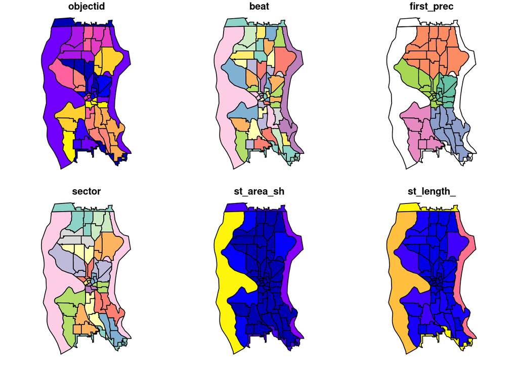

```r
plot(beats)
```

From the output above it looks like the bounding box is in long/lat which is what we’ll need for our shootings data.

```r
# Save workspace
save.image(file='data.RData')
```